# ChIP-seq Analysis Report 2

Dr.Parul Kulshreshtha

This R notebook gives protocol to geenrate the following plots for the ChIPseq analysis:

1.Generation of Tagmatrix lists: TagMatrixList is a data structure that stores the ChIP-seq signal (peak coverage) around transcription start sites (TSS) for each sample. What it does:

Takes your peaks (binding sites) and promoter regions (TSS ± 3kb windows) Calculates signal intensity at each position relative to the TSS (-3000bp to +3000bp) Stores this as a matrix where:

Rows = individual genes/promoters Columns = positions relative to TSS (e.g., -3000, -2999, …, 0 (TSS), …, +2999, +3000) Values = peak coverage/signal strength at each position

Why it’s important:

Enables visualization: Used by tagHeatmap() to show individual gene patterns and plotAvgProf() to show average binding profiles Quantifies TSS enrichment: Shows whether your transcription factor binds near TSS or elsewhere Allows comparisons: You can compare Control vs KLF5-KO to see how binding patterns change

2.Tag Heatmap: Visualizes the intensity and distribution of ChIP-seq signal around transcription start sites (TSS) for individual peaks, revealing binding strength patterns and identifying clusters of genes with similar regulatory profiles.

3.Average Profile Plot (plotAvgProf): Shows the aggregate binding signal across all promoters relative to TSS, enabling quantitative comparison of transcription factor occupancy between conditions and identifying enrichment patterns.

```r
library(ChIPseeker)
library(TxDb.Hsapiens.UCSC.hg19.knownGene)
txdb <- TxDb.Hsapiens.UCSC.hg19.knownGene
```

```r
# Load required package
library(ChIPseeker)

# Define BED files with full paths
peak_files <- list(
  "Control.FOXA1" = "~/CHIP_Analysis/GSM1919987_CFPAC1.wtKLF5_FOXA1_vs_INPUT.CAPAN1_peaks.bed",
  "KLF5-KO.FOXA1" = "~/CHIP_Analysis/GSM1919985_CFPAC1.crKLF5_FOXA1_vs_INPUT.CAPAN1_peaks.bed",
  "Control.ELF3"  = "~/CHIP_Analysis/GSM1919986_CFPAC1.wtKLF5.ELF3_vs_INPUT.CAPAN1_peaks.bed",
  "KLF5-KO.ELF3"  = "~/CHIP_Analysis/GSM1919984_CFPAC1.crKLF5.ELF3_vs_INPUT.CAPAN1_peaks.bed"
)

# Verify files exist
sapply(peak_files, file.exists)
```

```
## Control.FOXA1 KLF5-KO.FOXA1  Control.ELF3  KLF5-KO.ELF3
##          TRUE          TRUE          TRUE          TRUE
```

```r
# Read BED files into GRanges
peak_list <- lapply(peak_files, readPeakFile)

# Verify successful loading
names(peak_list)
```

```
## [1] "Control.FOXA1" "KLF5-KO.FOXA1" "Control.ELF3"  "KLF5-KO.ELF3"
```

TagMatrixList is a data structure that stores the ChIP-seq signal (peak coverage) around transcription start sites (TSS) for each sample. What it does:

Takes your peaks (binding sites) and promoter regions (TSS ± 3kb windows) Calculates signal intensity at each position relative to the TSS (-3000bp to +3000bp) Stores this as a matrix where:

Rows = individual genes/promoters Columns = positions relative to TSS (e.g., -3000, -2999, …, 0 (TSS), …, +2999, +3000) Values = peak coverage/signal strength at each position

Why it’s important:

Enables visualization: Used by tagHeatmap() to show individual gene patterns and plotAvgProf() to show average binding profiles Quantifies TSS enrichment: Shows whether your transcription factor binds near TSS or elsewhere Allows comparisons: You can compare Control vs KLF5-KO to see how binding patterns change

```r
# Load libraries
library(ChIPseeker)
library(TxDb.Hsapiens.UCSC.hg19.knownGene)

# Define TxDb object
txdb <- TxDb.Hsapiens.UCSC.hg19.knownGene

# Define peak files with full paths from home directory
peak_files <- list(
  "Control_FOXA1" = "~/CHIP_Analysis/GSM1919987_CFPAC1.wtKLF5_FOXA1_vs_INPUT.CAPAN1_peaks.bed",
  "KLF5_KO_FOXA1" = "~/CHIP_Analysis/GSM1919985_CFPAC1.crKLF5_FOXA1_vs_INPUT.CAPAN1_peaks.bed",
  "Control_ELF3"  = "~/CHIP_Analysis/GSM1919986_CFPAC1.wtKLF5.ELF3_vs_INPUT.CAPAN1_peaks.bed",
  "KLF5_KO_ELF3"  = "~/CHIP_Analysis/GSM1919984_CFPAC1.crKLF5.ELF3_vs_INPUT.CAPAN1_peaks.bed"
)

# Verify files exist
sapply(peak_files, file.exists)
```

```
## Control_FOXA1 KLF5_KO_FOXA1  Control_ELF3  KLF5_KO_ELF3
##          TRUE          TRUE          TRUE          TRUE
```

```r
# Read peaks
peak_GR <- lapply(peak_files, readPeakFile)

# Limit to top 5000 peaks per sample
peak_GR_top <- lapply(peak_GR, function(gr) {
  if ("score" %in% colnames(mcols(gr))) {
    gr[order(gr$score, decreasing = TRUE)][1:min(5000, length(gr))]
  } else {
    gr[1:min(5000, length(gr))]
  }
})

# Get promoter regions
promoters <- getPromoters(TxDb = txdb, upstream = 3000, downstream = 3000)
```

```
## >> Using Genome: hg19 ...
## >> Using Genome: hg19 ...
```

```r
# Generate tag matrices using top peaks only
tagMatrixList <- lapply(peak_GR_top, getTagMatrix, windows = promoters)
```

```
## >> preparing start_site regions by gene... 2026-01-16 08:20:21
## >> preparing tag matrix...  2026-01-16 08:20:21
## >> preparing start_site regions by gene... 2026-01-16 08:20:26
## >> preparing tag matrix...  2026-01-16 08:20:26
## >> preparing start_site regions by gene... 2026-01-16 08:20:29
## >> preparing tag matrix...  2026-01-16 08:20:29
## >> preparing start_site regions by gene... 2026-01-16 08:20:31
## >> preparing tag matrix...  2026-01-16 08:20:31
```

```r
# Verify successful creation
print(paste("Tag matrices created for", length(tagMatrixList), "samples"))
```

```
## [1] "Tag matrices created for 4 samples"
```

```r
names(tagMatrixList)
```

```
## [1] "Control_FOXA1" "KLF5_KO_FOXA1" "Control_ELF3"  "KLF5_KO_ELF3"
```

```r
# Limit to top 5000 peaks per sample (faster processing)
peak_GR_top <- lapply(peak_GR, function(gr) {
  # Check if "score" column exists in the peak data
  if ("score" %in% colnames(mcols(gr))) {
    # If score exists: sort by score (highest first), take top 5000
    gr[order(gr$score, decreasing = TRUE)][1:min(5000, length(gr))]
  } else {
    # If no score: just take first 5000 peaks
    gr[1:min(5000, length(gr))]
  }
})
```

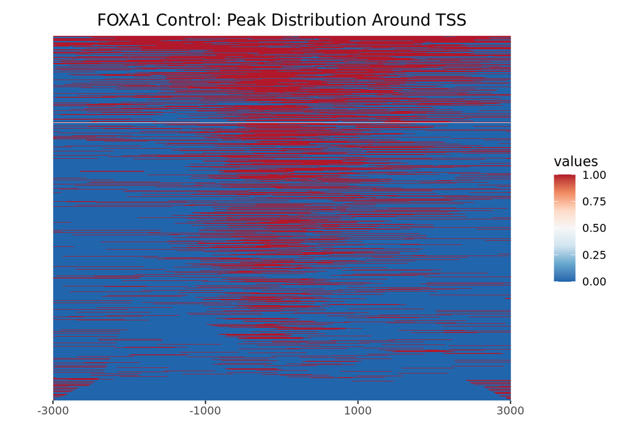

```r
# Generate TSS heatmaps for each condition

# FOXA1 Control
tagHeatmap(tagMatrixList["Control_FOXA1"],
           title = "FOXA1 Control: Peak Distribution Around TSS")
```

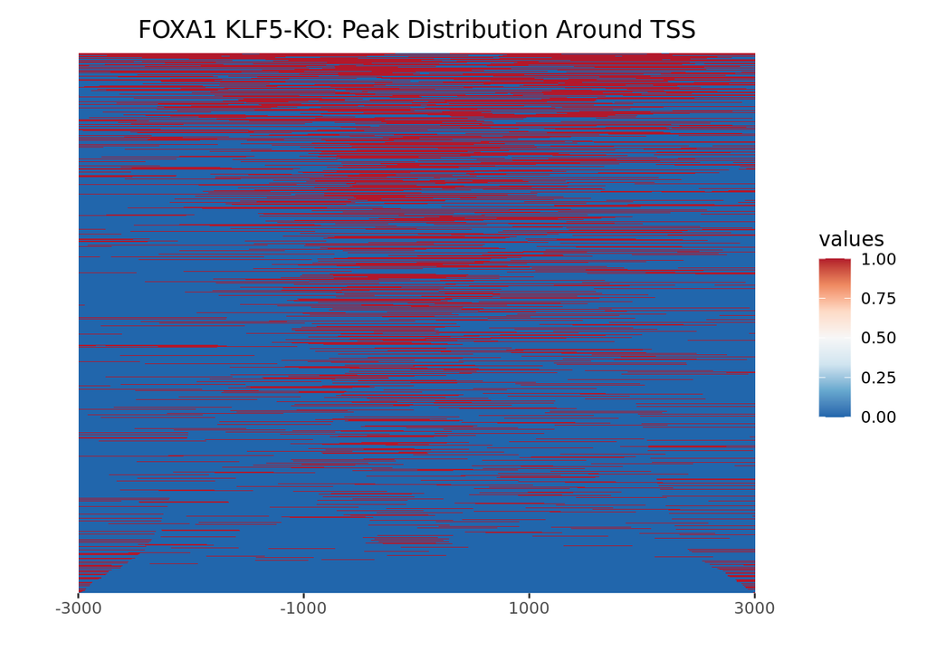

```r
# FOXA1 KLF5-KO
tagHeatmap(tagMatrixList["KLF5_KO_FOXA1"],
           title = "FOXA1 KLF5-KO: Peak Distribution Around TSS")
```

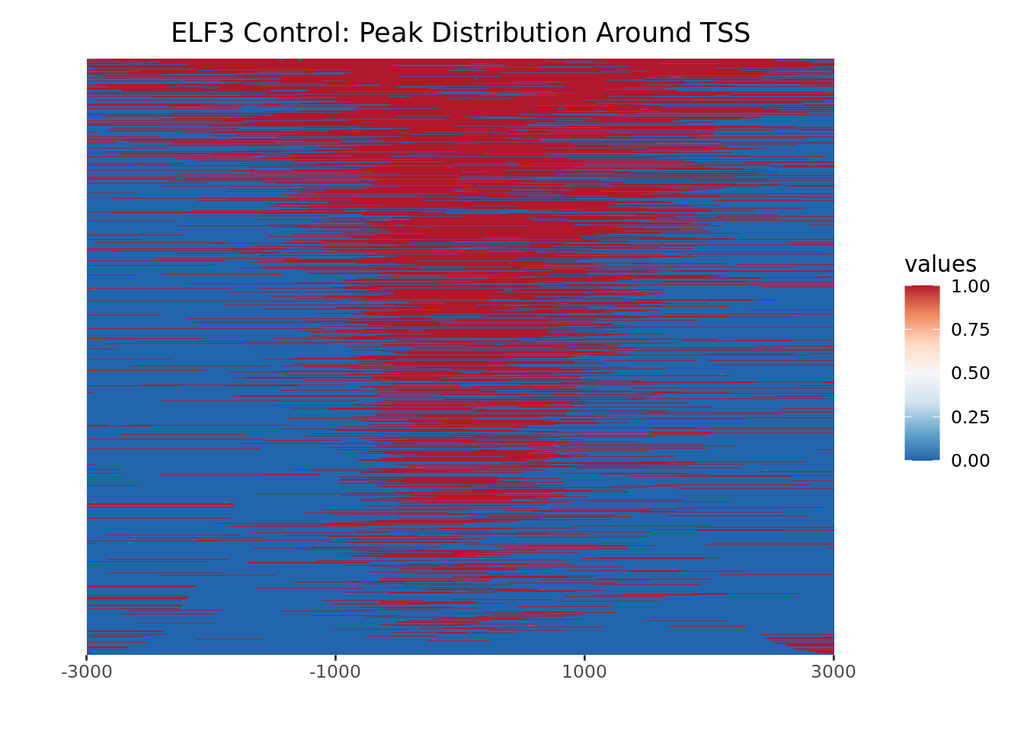

```r
# ELF3 Control
tagHeatmap(tagMatrixList["Control_ELF3"],
           title = "ELF3 Control: Peak Distribution Around TSS")
```

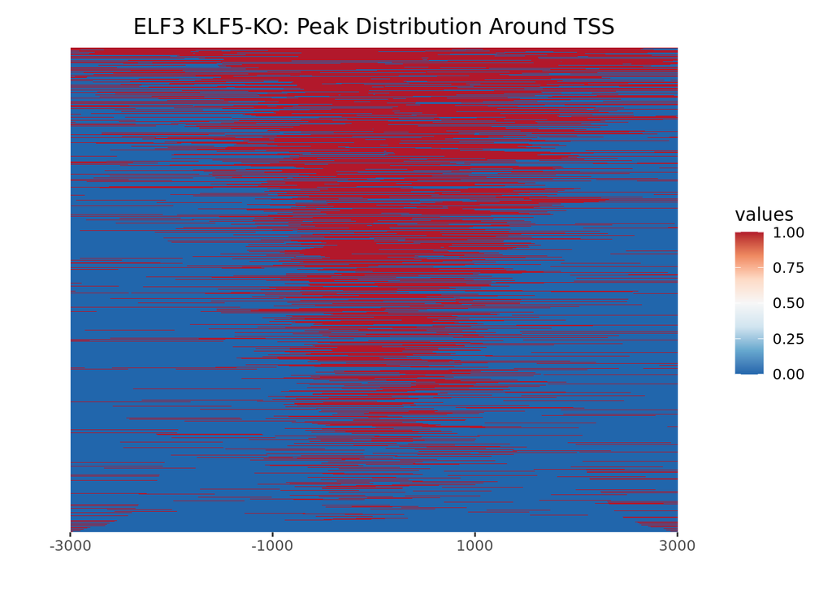

```r
# ELF3 KLF5-KO
tagHeatmap(tagMatrixList["KLF5_KO_ELF3"],
           title = "ELF3 KLF5-KO: Peak Distribution Around TSS")
```

```r
# Average Profile of Binding Density Around Promoters (TSS)
library(ChIPseeker)
library(TxDb.Hsapiens.UCSC.hg19.knownGene)
library(GenomicRanges)

# Define the Transcriptome Database
txdb <- TxDb.Hsapiens.UCSC.hg19.knownGene

# Peak files with full paths from home directory
peak_files <- list(
  "Control_FOXA1" = "~/CHIP_Analysis/GSM1919987_CFPAC1.wtKLF5_FOXA1_vs_INPUT.CAPAN1_peaks.bed",
  "KLF5_KO_FOXA1" = "~/CHIP_Analysis/GSM1919985_CFPAC1.crKLF5_FOXA1_vs_INPUT.CAPAN1_peaks.bed",
  "Control_ELF3"  = "~/CHIP_Analysis/GSM1919986_CFPAC1.wtKLF5.ELF3_vs_INPUT.CAPAN1_peaks.bed",
  "KLF5_KO_ELF3"  = "~/CHIP_Analysis/GSM1919984_CFPAC1.crKLF5.ELF3_vs_INPUT.CAPAN1_peaks.bed"
)

# Verify files exist
sapply(peak_files, file.exists)
```

```
## Control_FOXA1 KLF5_KO_FOXA1  Control_ELF3  KLF5_KO_ELF3
##          TRUE          TRUE          TRUE          TRUE
```

```r
# Read peaks
peak_GR <- lapply(peak_files, readPeakFile)

## 1. Define Target Regions (Promoter Windows)
# Use getPromoters() to define the TSS +/- 3kb windows
target_windows <- ChIPseeker::getPromoters(TxDb = txdb, upstream = 3000, downstream = 3000)
```

```
## >> Using Genome: hg19 ...
## >> Using Genome: hg19 ...
```

```r
## 2. Generate Tag Matrix List
# Calculate the read count/tag density for every promoter region
tagMatrixList <- lapply(peak_GR, function(peak) {
  ChIPseeker::getTagMatrix(peak, windows = target_windows)
})
```

```
## >> preparing start_site regions by gene... 2026-01-16 08:23:02
## >> preparing tag matrix...  2026-01-16 08:23:02
## >> preparing start_site regions by gene... 2026-01-16 08:23:12
## >> preparing tag matrix...  2026-01-16 08:23:12
## >> preparing start_site regions by gene... 2026-01-16 08:23:23
## >> preparing tag matrix...  2026-01-16 08:23:23
## >> preparing start_site regions by gene... 2026-01-16 08:23:32
## >> preparing tag matrix...  2026-01-16 08:23:32
```

```
## >> plotting figure...             2026-01-16 08:23:37
```

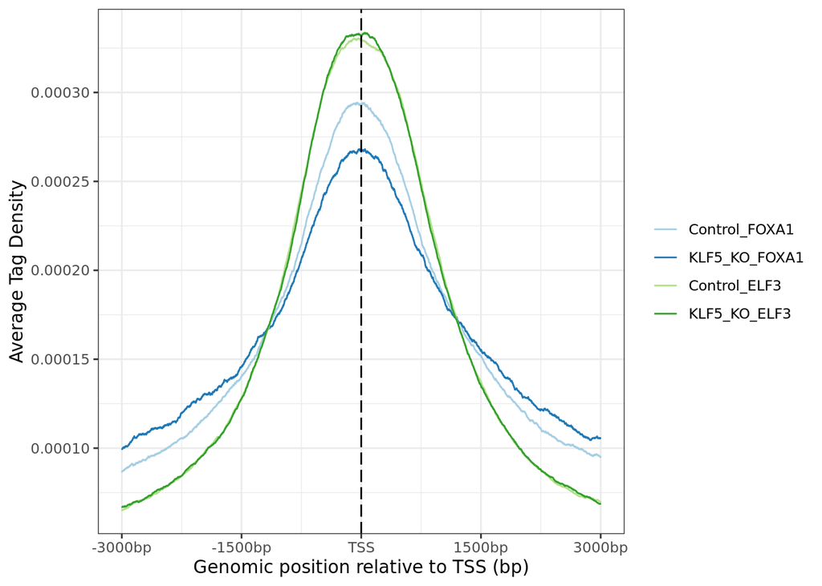

```r
## 3. Plot Average Profile
# Visualize the average density for each sample
plotAvgProf(
    tagMatrixList,
    xlim = c(-3000, 3000),
    xlab = "Genomic position relative to TSS (bp)",
    ylab = "Average Tag Density"
)
```